# Лабораторная работа №14

Архитектура компьютеров

Мустафина А. Ю.

Российский университет дружбы народов, Москва, Россия

17 мая 2025

## Цель работы

Изучить основы программирования в оболочке ОС UNIX. Научиться писать более сложные командные файлы с использованием логических управляющих конструкций и циклов.

## Выполнение лабораторной работы

Написала командный файл, реализующий упрощённый механизм семафоров. (рис. 1).

[figure not shown]

1

## Выполнение лабораторной работы

Даю права на исполнение (рис. 2).

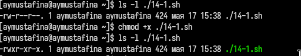

2

## Выполнение лабораторной работы

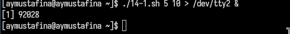

3

## Выполнение лабораторной работы

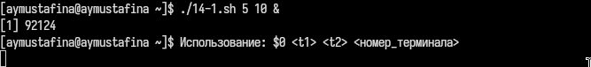

4

## Выполнение лабораторной работы

[figure not shown]

5

## Выполнение лабораторной работы

Реализовала команду man с помощью командного файла (рис. 6).

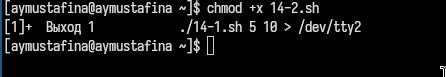

6

## Выполнение лабораторной работы

Исполнение (рис. 7).

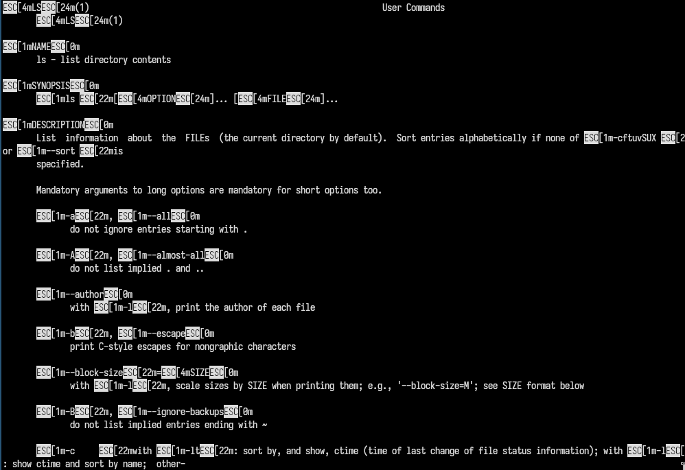

7

## Выполнение лабораторной работы

Используя встроенную переменную $RANDOM, написала командный файл, генерирую- щий случайную последовательность букв латинского алфавита (рис. 8).

[figure not shown]

8

## Выполнение лабораторной работы

Исполнение (рис. 9).

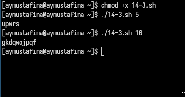

9

## Контрольные вопросы

1. Найдите синтаксическую ошибку в следующей строке: while [$1 != “exit”]

Синтаксическая ошибка: Ошибка в строке 1: while [$1 != “exit”] должна быть исправлена на while [ “$1” != “exit” ].

2. Как объединить (конкатенация) несколько строк в одну?

Конкатенация строк: Можно использовать string1=“Hello” и string2=“World” и затем combined=“$string1 $string2”.

## Контрольные вопросы

3. Найдите информацию об утилите seq. Какими иными способами можно реализовать её функционал при программировании на bash?

Утилита seq: seq генерирует последовательность чисел. Альтернативы: циклы for, while, использование printf.

4. Какой результат даст вычисление выражения $((10/3))?

Результат выражения: Выражение $((10/3)) даст результат 3 (целочисленное деление).

## Контрольные вопросы

5. Укажите кратко основные отличия командной оболочки zsh от bash.

Отличия zsh от bash: zsh имеет более продвинутую автозаполнение, поддержку плагинов, улучшенные возможности настройки и более мощный механизм управления задачами.

6. Проверьте, верен ли синтаксис данной конструкции 1 for ((a=1; a <= LIMIT; a++))

Проверка синтаксиса: Синтаксис конструкции for ((a=1; a <= LIMIT; a++)) верен, если LIMIT определена.

## Контрольные вопросы

7. Сравните язык bash с какими-либо языками программирования. Какие преимущества у bash по сравнению с ними? Какие недостатки?

Сравнение bash с другими языками: Bash — это скриптовый язык, удобный для автоматизации задач. Преимущества: простота и доступность для системного администрирования. Недостатки: ограниченные возможности по сравнению с полноценными языками программирования (например, отсутствие строгой типизации, сложность в отладке и ограниченная поддержка структур данных).

## Выводы

Изучила основы программирования в оболочке ОС UNIX. Научидась писать более сложные командные файлы с использованием логических управляющих конструкций и циклов.